# EDA Danych dotyczących Irysów.

### 1. Cel analizy

Celem tej analizy jest zbadanie i porównanie ze sobą danych opisujących trzy gatunki kwiatu IRIS:

Iris-setosa, Iris_versicolor i Iris_virginica

### 2. Pozyskanie i ogólne zrozumienie danych

Zbiór danych (25__iris.csv) zawiera informacje o trzech gatunkach irysów: Iris setosa, Iris versicolor i Iris virginica.

Dane obejmują pomiary czterech cech: długość i szerokość działki kielicha oraz długość i szerokość płatka. Każdy wiersz w zbiorze danych reprezentuje pojedynczy kwiat, a wartości pomiarów są podane w centymetrach. Zbiór składa się z 150 próbek, po 50 dla każdego gatunku.

Kolumny:

- **długość kielicha (sepal length)** - Długość kielicha w cm
- **szerokość kielicha (sepal width)** - Szerokość kielicha w cm
- **długość płatka (petal length)** - Długość płatka w cm
- **szerokość płatka (petal width)** - Szerokość płatka w cm
- **klasa (class)** - Klasa irysa (setosa, versicolor, virginica)

### 3. Przygotowanie danych (Data Cleaning i Preprocessing)

|  | długość kielicha (sepal length) | szerokość kielicha (sepal width) | długość płatka (petal length) | szerokość płatka (petal width) | klasa (class) |
| --- | --- | --- | --- | --- | --- |
| 0 | 5.1 | 3.5 | 1.4 | 0.2 | Iris-setosa |
| 1 | 4.9 | 3.0 | 1.4 | 0.2 | Iris-setosa |
| 2 | 4.7 | 3.2 | 1.3 | 0.2 | Iris-setosa |
| 3 | 4.6 | 3.1 | 1.5 | 0.2 | Iris-setosa |
| 4 | 5.0 | 3.6 | 1.4 | 0.2 | Iris-setosa |
| ... | ... | ... | ... | ... | ... |
| 145 | 6.7 | 3.0 | 5.2 | 2.3 | Iris-virginica |
| 146 | 6.3 | 2.5 | 5.0 | 1.9 | Iris-virginica |
| 147 | 6.5 | 3.0 | 5.2 | 2.0 | Iris-virginica |
| 148 | 6.2 | 3.4 | 5.4 | 2.3 | Iris-virginica |
| 149 | 5.9 | 3.0 | 5.1 | 1.8 | Iris-virginica |

150 rows × 5 columns

```
Iris-setosa        50
Iris-versicolor    50
Iris-virginica     50
Name: klasa (class), dtype: int64
```

|  | długość kielicha (sepal length) | szerokość kielicha (sepal width) | długość płatka (petal length) | szerokość płatka (petal width) | klasa (class) |
| --- | --- | --- | --- | --- | --- |
| 0 | 5.1 | 3.5 | 1.4 | 0.2 | Iris-setosa |
| 1 | 4.9 | 3.0 | 1.4 | 0.2 | Iris-setosa |
| 2 | 4.7 | 3.2 | 1.3 | 0.2 | Iris-setosa |
| 3 | 4.6 | 3.1 | 1.5 | 0.2 | Iris-setosa |
| 4 | 5.0 | 3.6 | 1.4 | 0.2 | Iris-setosa |
| 5 | 5.4 | 3.9 | 1.7 | 0.4 | Iris-setosa |
| 6 | 4.6 | 3.4 | 1.4 | 0.3 | Iris-setosa |
| 7 | 5.0 | 3.4 | 1.5 | 0.2 | Iris-setosa |
| 8 | 4.4 | 2.9 | 1.4 | 0.2 | Iris-setosa |
| 9 | 4.9 | 3.1 | 1.5 | 0.1 | Iris-setosa |
| 10 | 5.4 | 3.7 | 1.5 | 0.2 | Iris-setosa |
| 11 | 4.8 | 3.4 | 1.6 | 0.2 | Iris-setosa |
| 12 | 4.8 | 3.0 | 1.4 | 0.1 | Iris-setosa |
| 13 | 4.3 | 3.0 | 1.1 | 0.1 | Iris-setosa |
| 14 | 5.8 | 4.0 | 1.2 | 0.2 | Iris-setosa |
| 15 | 5.7 | 4.4 | 1.5 | 0.4 | Iris-setosa |
| 16 | 5.4 | 3.9 | 1.3 | 0.4 | Iris-setosa |
| 17 | 5.1 | 3.5 | 1.4 | 0.3 | Iris-setosa |
| 18 | 5.7 | 3.8 | 1.7 | 0.3 | Iris-setosa |
| 19 | 5.1 | 3.8 | 1.5 | 0.3 | Iris-setosa |
| 20 | 5.4 | 3.4 | 1.7 | 0.2 | Iris-setosa |
| 21 | 5.1 | 3.7 | 1.5 | 0.4 | Iris-setosa |
| 22 | 4.6 | 3.6 | 1.0 | 0.2 | Iris-setosa |
| 23 | 5.1 | 3.3 | 1.7 | 0.5 | Iris-setosa |
| 24 | 4.8 | 3.4 | 1.9 | 0.2 | Iris-setosa |
| 25 | 5.0 | 3.0 | 1.6 | 0.2 | Iris-setosa |
| 26 | 5.0 | 3.4 | 1.6 | 0.4 | Iris-setosa |
| 27 | 5.2 | 3.5 | 1.5 | 0.2 | Iris-setosa |
| 28 | 5.2 | 3.4 | 1.4 | 0.2 | Iris-setosa |
| 29 | 4.7 | 3.2 | 1.6 | 0.2 | Iris-setosa |

[output cut: 120 more lines]

```
<class 'pandas.core.frame.DataFrame'>
RangeIndex: 150 entries, 0 to 149
Data columns (total 5 columns):
 #   Column                            Non-Null Count  Dtype
---  ------                            --------------  -----
 0   długość kielicha (sepal length)   150 non-null    float64
 1   szerokość kielicha (sepal width)  150 non-null    float64
 2   długość płatka (petal length)     150 non-null    float64
 3   szerokość płatka (petal width)    150 non-null    float64
 4   klasa (class)                     150 non-null    object
dtypes: float64(4), object(1)
memory usage: 6.0+ KB
```

```
długość kielicha (sepal length)     35
szerokość kielicha (sepal width)    23
długość płatka (petal length)       43
szerokość płatka (petal width)      22
klasa (class)                        3
dtype: int64
```

|  | długość kielicha (sepal length) | szerokość kielicha (sepal width) | długość płatka (petal length) | szerokość płatka (petal width) | klasa (class) |
| --- | --- | --- | --- | --- | --- |
| count | 150.000000 | 150.000000 | 150.000000 | 150.000000 | 150 |
| unique | NaN | NaN | NaN | NaN | 3 |
| top | NaN | NaN | NaN | NaN | Iris-setosa |
| freq | NaN | NaN | NaN | NaN | 50 |
| mean | 5.843333 | 3.054000 | 3.758667 | 1.198667 | NaN |
| std | 0.828066 | 0.433594 | 1.764420 | 0.763161 | NaN |
| min | 4.300000 | 2.000000 | 1.000000 | 0.100000 | NaN |
| 25% | 5.100000 | 2.800000 | 1.600000 | 0.300000 | NaN |
| 50% | 5.800000 | 3.000000 | 4.350000 | 1.300000 | NaN |
| 75% | 6.400000 | 3.300000 | 5.100000 | 1.800000 | NaN |
| max | 7.900000 | 4.400000 | 6.900000 | 2.500000 | NaN |

```
długość kielicha (sepal length)     0
szerokość kielicha (sepal width)    0
długość płatka (petal length)       0
szerokość płatka (petal width)      0
klasa (class)                       0
dtype: int64
```

```
długość kielicha (sepal length)     0
szerokość kielicha (sepal width)    0
długość płatka (petal length)       0
szerokość płatka (petal width)      0
klasa (class)                       0
dtype: int64
```

|  | długość kielicha (sepal length) | szerokość kielicha (sepal width) | długość płatka (petal length) | szerokość płatka (petal width) | klasa (class) | czy_duplikat | status |
| --- | --- | --- | --- | --- | --- | --- | --- |
| 9 | 4.9 | 3.1 | 1.5 | 0.1 | Iris-setosa | False | ORYGINAŁ |
| 34 | 4.9 | 3.1 | 1.5 | 0.1 | Iris-setosa | True | DUPLIKAT |
| 37 | 4.9 | 3.1 | 1.5 | 0.1 | Iris-setosa | True | DUPLIKAT |
| 101 | 5.8 | 2.7 | 5.1 | 1.9 | Iris-virginica | False | ORYGINAŁ |
| 142 | 5.8 | 2.7 | 5.1 | 1.9 | Iris-virginica | True | DUPLIKAT |

Mimo występowania "duplikatów", postanawiam ich nie usuwać, dokładność danych pomiarowych nie jest wystarczająco duża i można uznać, że duplikaty NIE powstały w skutek niepoprawnego wprowadzenia danych, prawdopodobnie wynikają one z występowania prawie identycznych kwiatów.

### 4. Wstępna eksploracja danych (EDA – Exploratory Data Analysis)

|  | min | kwartyl_25% | mediana (kwartyl 50%) | kwartyl_75% | max | średnia | odchylenie_std |
| --- | --- | --- | --- | --- | --- | --- | --- |
| długość kielicha (sepal length) | 4.3 | 5.1 | 5.80 | 6.4 | 7.9 | 5.84 | 0.83 |
| szerokość kielicha (sepal width) | 2.0 | 2.8 | 3.00 | 3.3 | 4.4 | 3.05 | 0.43 |
| długość płatka (petal length) | 1.0 | 1.6 | 4.35 | 5.1 | 6.9 | 3.76 | 1.76 |
| szerokość płatka (petal width) | 0.1 | 0.3 | 1.30 | 1.8 | 2.5 | 1.20 | 0.76 |

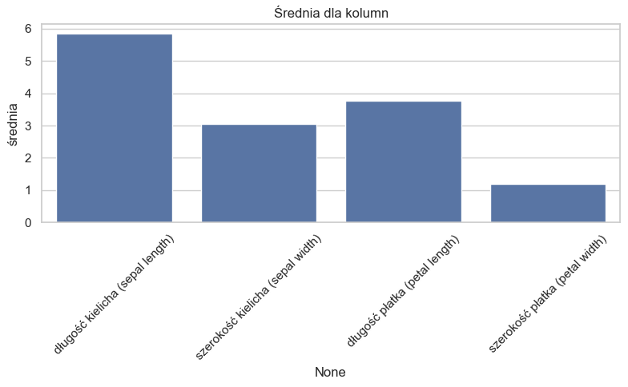

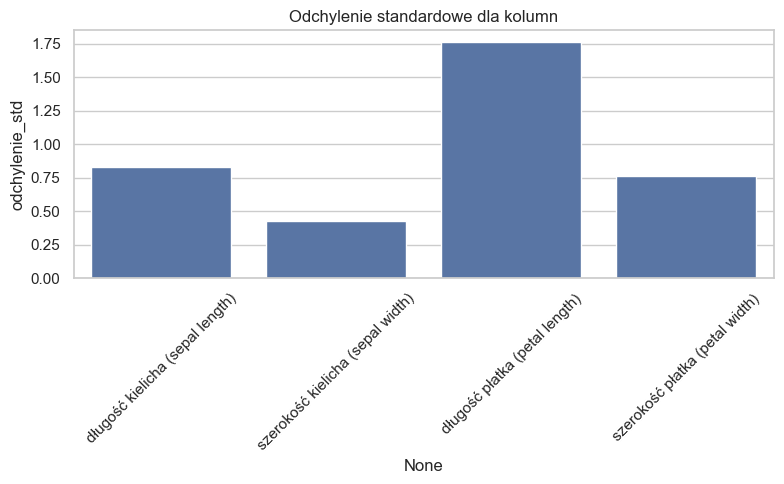

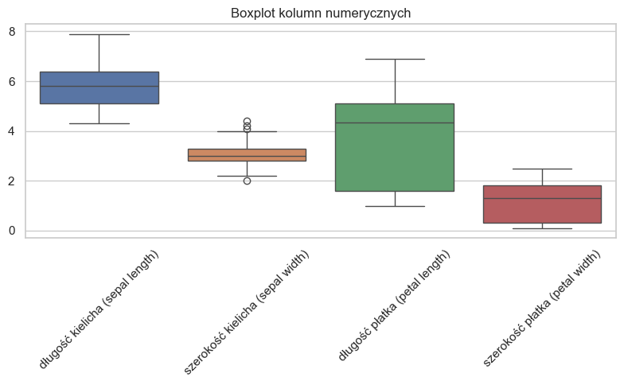

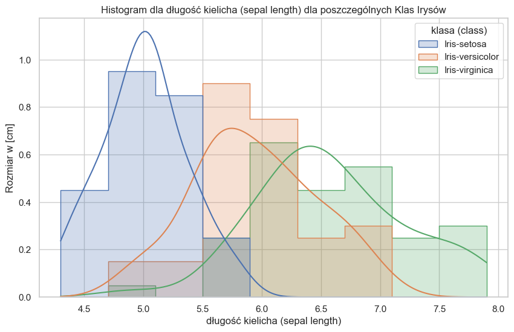

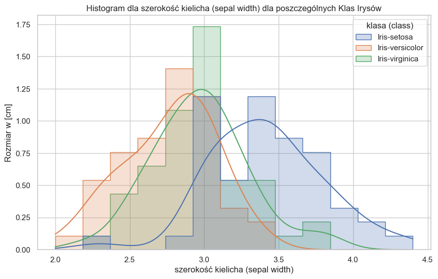

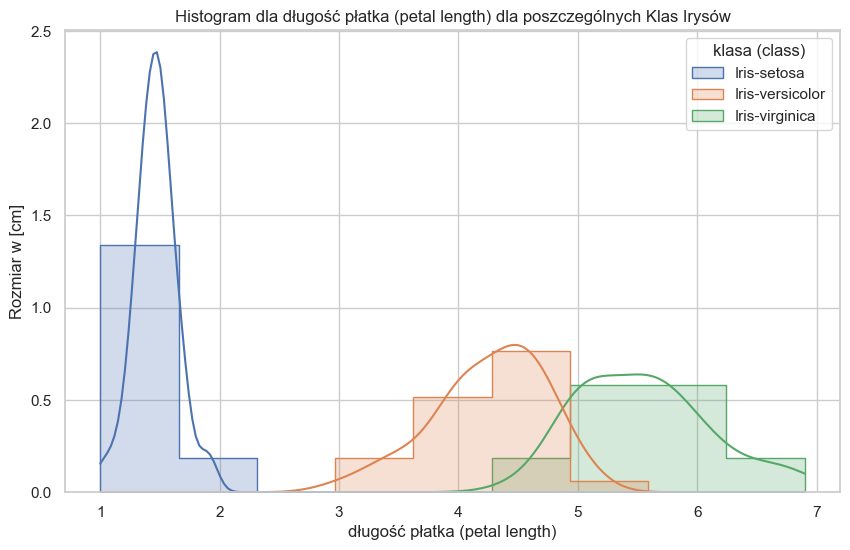

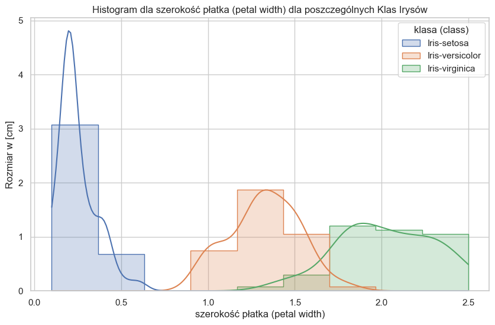

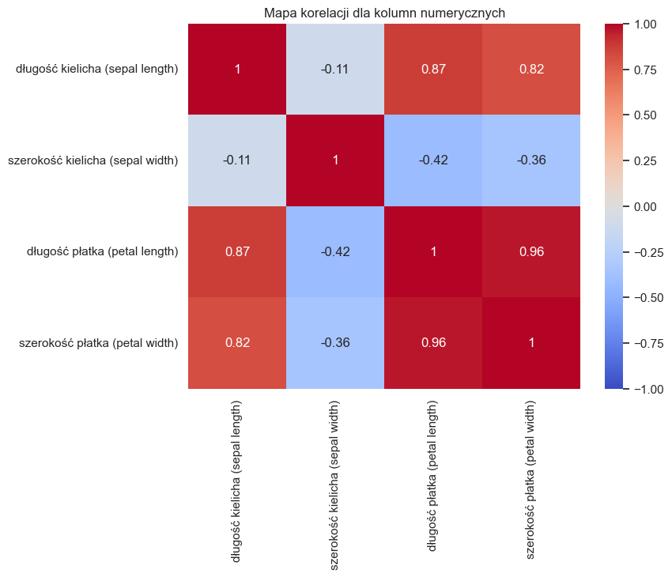

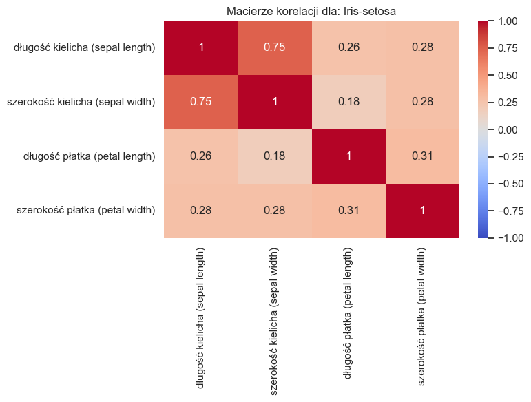

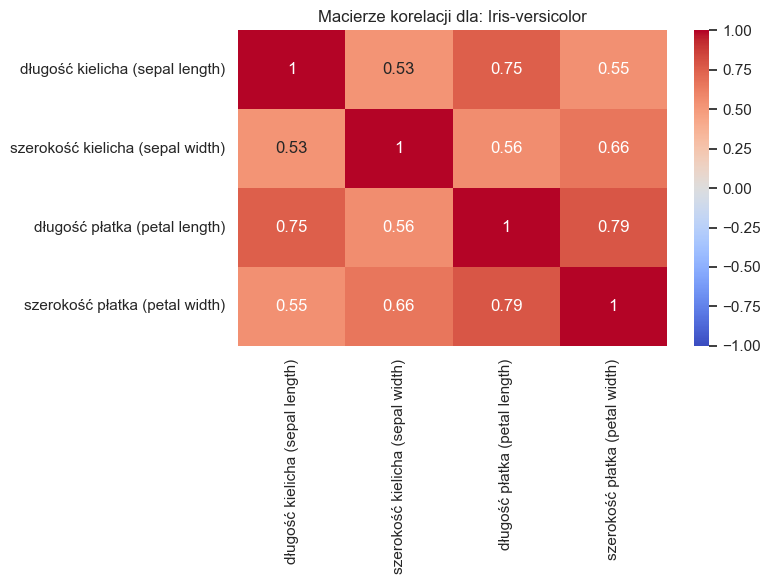

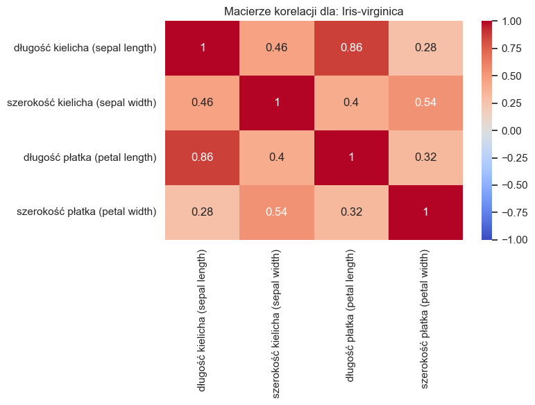

|  | klasa (class) | długość kielicha (sepal length) mean | długość kielicha (sepal length) median | szerokość kielicha (sepal width) mean | szerokość kielicha (sepal width) median | długość płatka (petal length) mean | długość płatka (petal length) median | szerokość płatka (petal width) mean | szerokość płatka (petal width) median |
| --- | --- | --- | --- | --- | --- | --- | --- | --- | --- |
| 0 | Iris-setosa | 5.006 | 5.0 | 3.418 | 3.4 | 1.464 | 1.50 | 0.244 | 0.2 |
| 1 | Iris-versicolor | 5.936 | 5.9 | 2.770 | 2.8 | 4.260 | 4.35 | 1.326 | 1.3 |
| 2 | Iris-virginica | 6.588 | 6.5 | 2.974 | 3.0 | 5.552 | 5.55 | 2.026 | 2.0 |

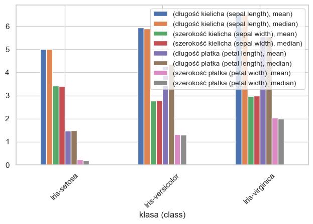

### 5. Wnioski i rekomendacje

Gatunek Irys-Setosa ma najkrótsze i zarazem najszersze kielichy, ma również najkrótsze i najwęższe płatki. Warotści długości kielicha oraz długości i szerokości płatków charakteryzują się małym rozrzutem danych.

Gatunek Irys-Versicolor ma średniej długości kielichy i płatki, płatki mają również średnią szerokość. Ma za to najwęższe kielichy.

Gatunek Irys-Virginica posiada najdłuższe kielichy oraz najdłuższe i najszersze płatki. Jeśli chodzi o szerokość kielicha, to ustępuje on Irys-Setosa.

### 6. Raportowanie i prezentacja wyników

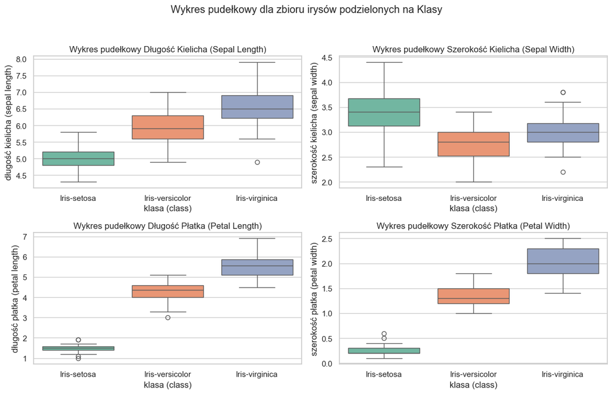